# Esercitazione N.3

Nonlinearità: logaritmi

Autore/Autrice

Andrea Recine

Data di Pubblicazione

28 aprile 2026

## 1 Setup

```r
library(tidyverse)
library(knitr)
library(tinytable)
library(modelsummary)
library(fixest)
library(wooldridge)
```

```r
data("wage1", package = "wooldridge")
```

## 2 Introduzione

Le trasformazioni logaritmiche permettono di modellare le relazioni in termini “percentuali” invece che lineari. Ad esempio potremmo essere interessati a modellare l’effetto di un anno in più di istruzione sui salari in termini percentuali: ogni anno di istruzione aumenta i salari di una certa percentuale.

Consideriamo:

$$\log(wage_i) = \beta_0 + \beta_1 \, educ_i + u_i$$

E stimiamo:

```r
reg_logwage <- feols(log(wage) ~ educ, data = wage1, vcov = "hetero")
```

Prendendo l’esponenziale si scrive:
$$wage_i = \exp(\beta_0 + \beta_1 \, educ_i + u_i)$$

**Nota:** Per visualizzare graficamente i valori predetti assumiamo $u_i = 0$, cioè mostriamo $\exp(\hat{\beta}_0 + \hat{\beta}_1 educ)$. Come calcolare correttamente le previsioni di $Y$ quando il modello è in $\log(Y)$ è discusso nel paragrafo 8.2 di Stock e Watson (pp. 215-216).

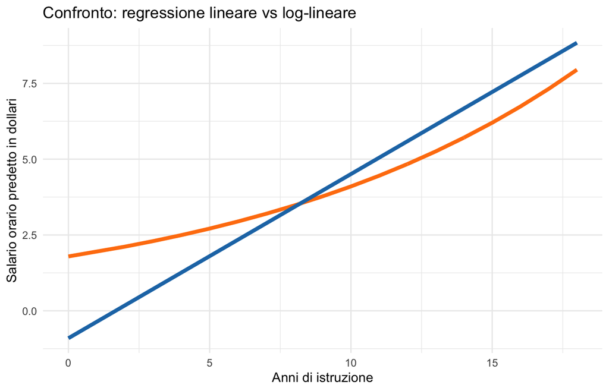

```r
# Previsione valori stimati dal modello log-lineare
wage1 <- wage1 %>%
  mutate(
    logwage_pred = predict(reg_logwage),    #valori predetti in log
    wage_pred = exp(logwage_pred)           #salario predetto in scala originale
  )

# Grafico con curva log-lineare + retta OLS
ggplot(wage1, aes(x = educ)) +
  geom_line(aes(y = wage_pred), color = "#ff7f0e", linewidth = 1.5) +          # curva log-lineare
  geom_smooth(aes(y = wage), method = "lm", se = FALSE, color = "#1f77b4", linewidth = 1.5) + # retta OLS
  labs(
    title = "Confronto: regressione lineare vs log-lineare",
    x = "Anni di istruzione",
    y = "Salario orario predetto in dollari"
  ) +
  theme_minimal()
```

Poiché nella specificazione log-lin la variazione percentuale di $wage$ è la stessa per ogni anno aggiuntivo di istruzione, la variazione in dollari di $wage$ per un anno aggiuntivo di istruzione **cresce** all’aumentare di $educ$: il modello log-lin implica quindi rendimenti crescenti dell’istruzione, come si vede dalla curvatura della linea arancione rispetto alla retta OLS (in blu).

## 3 Log-lin vs livello

Stimiamo anche la regressione in livelli per confrontarla con la specificazione log-lin:

```r
reg_wage <- feols(wage ~ educ, data = wage1, vcov = "hetero")
```

```r
modelsummary(
  list("Livello" = reg_wage, "Log-lin" = reg_logwage),
  title = "Variabile dipendente: wage o log(wage)",
  gof_omit = "AIC|BIC|RMSE|R2 Adj."
)
```

Variabile dipendente: wage o log(wage)

|  | Livello | Log-lin |
| --- | --- | --- |
| (Intercept) | -0.905 | 0.584 |
|  | (0.725) | (0.098) |
| educ | 0.541 | 0.083 |
|  | (0.061) | (0.008) |
| Num.Obs. | 526 | 526 |
| R2 | 0.165 | 0.186 |

Il coefficiente $\beta_1$ della specificazione log-lin ha un’interpretazione in termini percentuali una volta moltiplicato per 100: in media, un anno aggiuntivo di istruzione è associato a un aumento del salario orario ($wage$) dell’8.3%.

**Importante:** $R^2$ mostra che $educ$ spiega circa il 18.6% della variazione in $\log(wage)$ (non in $wage$). $R^2$ non può essere usato per confrontare queste due regressioni perché hanno variabile dipendente diversa ($wage$ e $\log(wage)$, vedete Stock e Watson p. 215).

**AvvisoR² e confronto tra modelli**

L’$R^2$ è confrontabile **solo tra modelli con la stessa variabile dipendente $Y$**. Il motivo emerge dalle sue componenti:

$$R^2 = \frac{ESS}{TSS}$$

dove:

$$TSS = \sum_i (Y_i - \bar{Y})^2$$

dove $TSS$ dipende **solo** da $Y$ ed è la variazione totale di $Y$. $ESS$ invece è la variazione spiegata dalla regressione:

$$ESS = \sum_i (\hat{Y_i} - \bar{Y})^2$$

e dipende dalle stime del modello.

Ricordate invece che il cambiamento di unità di misura, sia della variabile dipendente che di quella indipendente, non cambia la bontà di adattamento del modello ai dati. L’ $R^2$ rimane invariato.

I logaritmi possono essere usati per trasformare la variabile dipendente $Y$, una variabile indipendente $X$ o entrambe (devono essere positive).

**NotaSpecificazioni in log**

| Forma del modello | Interpretazione |
| --- | --- |
| $\log(Y)$ ~ $X$ | A un’unità in più in $X$ è associata una variazione di $100 \cdot \beta_1$% in $Y$ |
| $Y$ ~ $\log(X)$ | A un aumento dell’1% in $X$ è associata una variazione di $0{,}01 \cdot \beta_1$ in $Y$ |
| $\log(Y)$ ~ $\log(X)$ | A un aumento dell’1% in $X$ è associata una variazione di $\beta_1$% in $Y$ |

### 3.1 Interpretazione dei coefficienti: log-lin, log-log e lin-log:

```r
reg_logwagelog <- feols(log(wage) ~ log(educ), data = wage1, vcov = "hetero")
reg_wagelog <- feols(wage ~ log(educ), data = wage1, vcov = "hetero")
modelsummary(
  list("Log-lin" = reg_logwage, "Log-log" = reg_logwagelog, "Lin-log" = reg_wagelog),
  title = "Variabile dipendente: log(wage) o wage",
  gof_omit = "AIC|BIC|RMSE|R2 Adj."
)
```

Variabile dipendente: log(wage) o wage

|  | Log-lin | Log-log | Lin-log |
| --- | --- | --- | --- |
| (Intercept) | 0.584 | -0.445 | -7.460 |
|  | (0.098) | (0.268) | (1.863) |
| educ | 0.083 |  |  |
|  | (0.008) |  |  |
| log(educ) |  | 0.825 | 5.330 |
|  |  | (0.106) | (0.757) |
| Num.Obs. | 526 | 524 | 524 |
| R2 | 0.186 | 0.149 | 0.128 |

- **Primo modello** (log-lin): un anno in più di istruzione è associato in media a un aumento dell’8.3% del salario orario.
- **Secondo modello** (log-log): un aumento dell’1% degli anni di istruzione è associato a un aumento, in media, del salario orario dello 0.825%. Il coefficiente è quindi un’elasticità: misura la variazione percentuale di $Y$ associata a **una** variazione percentuale di $X$.
- **Terzo modello** (lin-log): un aumento dell’1% degli anni di istruzione è associato a un aumento, in media, del salario orario di 0.053 dollari. Un aumento del 10% degli anni di istruzione è associato a un aumento, in media, del salario orario di 0.53 dollari (10 $\cdot$ 0.053).

**ConsiglioQuando usare il log?**

La scelta della forma funzionale dev’essere guidata dal ragionamento: quale interpretazione ha più senso?

I logaritmi sono tipicamente utilizzati per variabili monetarie (come $wage$ o reddito) o di livello (come la popolazione), soprattutto quando presentano ampia variazione. Sono invece meno appropriati per variabili misurate in anni (come $educ$ o età) o già espresse in percentuali (come il tasso di disoccupazione).

**ImportanteUnità di misura della variabile dipendente**

Con le variabili espresse in log, il cambiamento di unità di misura della variabile dipendente è irrilevante. Provate a esprimere il salario in centinaia di dollari creando $wage/100$ e fate la regressione su $educ$. Lo stesso vale se $X$ e $Y$ sono entrambe in log.

**L’intercetta invece cambierà**. Se $Y$ è in log, l’intercetta rappresenta il log del salario orario ($\log(wage)$) quando $educ$ è zero. Se $Y$ è in centinaia di dollari, l’intercetta rappresenta il salario orario ($wage$) quando $educ$ è zero.

## 4 Cambio di unità di misura e specificazione in log

In questa sezione confrontiamo i coefficienti e le intercette delle regressioni con $wage$ e $educ$ espresse in unità di misura diverse rispetto alla tabella di riferimento, quella con le stime originali dei tre modelli (`reg_logwage`, `reg_logwagelog`, `reg_wagelog`) della sezione precedente.

### 4.1 Variabile dipendente:

Esprimiamo $wage$ in decine di dollari e stimiamo la regressione di $\log(wage/10)$ su $educ$ e $\log(educ)$, e di $wage/10$ su $\log(educ)$. Nei modelli con $Y$ in log il coefficiente sulla variabile indipendente non cambia, mentre l’intercetta cambia sempre; nel modello lin-log cambiano sia il coefficiente che l’intercetta.

```r
reg_logwage_dec <- feols(log(wage/10) ~ educ, data = wage1, vcov = "hetero")
reg_logwagelog_dec <- feols(log(wage/10) ~ log(educ), data = wage1, vcov = "hetero")
reg_wagelog_dec <- feols(wage/10 ~ log(educ), data = wage1, vcov = "hetero")

modelsummary(
  list("Log-lin" = reg_logwage_dec, "Log-log" = reg_logwagelog_dec, "Lin-log" = reg_wagelog_dec),
  title = "Variabile dipendente: log(wage/10) o wage/10",
  gof_omit = "AIC|BIC|RMSE|R2 Adj."
)
```

Variabile dipendente: log(wage/10) o wage/10

|  | Log-lin | Log-log | Lin-log |
| --- | --- | --- | --- |
| (Intercept) | -1.719 | -2.747 | -0.746 |
|  | (0.098) | (0.268) | (0.186) |
| educ | 0.083 |  |  |
|  | (0.008) |  |  |
| log(educ) |  | 0.825 | 0.533 |
|  |  | (0.106) | (0.076) |
| Num.Obs. | 526 | 524 | 524 |
| R2 | 0.186 | 0.149 | 0.128 |

#### **Primo modello (log-lin)**

Un anno aggiuntivo di istruzione è associato a un aumento, in media, dell’8.3% del salario orario: il coefficiente su $educ$ non cambia.

L’intercetta invece cambia. Infatti:

$$\log(wage/10) = \log(wage) - \log(10)$$

quindi il modello diventa:

$$\log(wage) = \beta_0 + \log(10) + \beta_1 \, educ + u$$

Il termine $\log(10)$ viene assorbito dall’intercetta. La nuova intercetta è quindi:

$$\beta_0' = \beta_0 - \log(10) \approx 0.584 - 2.303 \approx -1.719$$

che coincide con il valore in tabella.

#### **Secondo modello (log-log)**

Un aumento dell’1% degli anni di istruzione è associato a un aumento, in media, del salario orario dello 0.825%: anche qui il coefficiente su $\log(educ)$ non cambia.

Per la stessa ragione del modello log-lin, la nuova intercetta diminuisce di $\log(10)$:

$$\beta_0' = \beta_0 - \log(10) = -0.445 - 2.303 \approx -2.748$$

che coincide con il valore in tabella.

#### **Terzo modello (lin-log)**

Qui $Y$ non è in log, quindi dividendo entrambi i lati per 10 il modello diventa:

$$\frac{wage}{10} = \frac{\beta_0}{10} + \frac{\beta_1}{10} \log(educ) + \frac{u}{10}$$

Cambiano sia l’intercetta che il coefficiente, entrambi divisi per 10:

$$\beta_0' = \frac{\beta_0}{10} = \frac{-7.460}{10} \approx -0.746$$
$$\beta_1' = \frac{\beta_1}{10} = \frac{5.330}{10} \approx 0.533$$

che coincidono con i valori in tabella. L’interpretazione diventa: un aumento dell’1% degli anni di istruzione è associato a un aumento, in media, del salario orario di 0.0053 decine di dollari ($\beta_1'/100$).

### 4.2 Variabile indipendente:

Esprimiamo $educ$ in mesi di istruzione invece che in anni (moltiplicando $educ$ per 12).

```r
wage1 <- wage1 %>%
  mutate(educ_monthly = educ * 12)

reg_logwage_monthly <- feols(log(wage) ~ educ_monthly, data = wage1, vcov = "hetero")
reg_logwagelog_monthly <- feols(log(wage) ~ log(educ_monthly), data = wage1, vcov = "hetero")
reg_wagelog_monthly <- feols(wage ~ log(educ_monthly), data = wage1, vcov = "hetero")

modelsummary(
  list("Log-lin" = reg_logwage_monthly, "Log-log" = reg_logwagelog_monthly, "Lin-log" = reg_wagelog_monthly),
  title = "Variabile dipendente: log(wage) o wage",
  gof_omit = "AIC|BIC|RMSE|R2 Adj."
)
```

Variabile dipendente: log(wage) o wage

|  | Log-lin | Log-log | Lin-log |
| --- | --- | --- | --- |
| (Intercept) | 0.584 | -2.495 | -20.704 |
|  | (0.098) | (0.531) | (3.741) |
| educ_monthly | 0.007 |  |  |
|  | (0.001) |  |  |
| log(educ_monthly) |  | 0.825 | 5.330 |
|  |  | (0.106) | (0.757) |
| Num.Obs. | 526 | 524 | 524 |
| R2 | 0.186 | 0.149 | 0.128 |

#### **Primo modello (log-lin)**

Un mese aggiuntivo di istruzione è associato a un aumento, in media, dello 0.7% del salario orario (0.007 è pari a 0.083/12).

L’intercetta è rimasta invariata perché rappresenta il log del salario orario quando $educ = 0$ (0 mesi di istruzione è lo stesso di 0 anni di istruzione).

#### **Secondo modello (log-log)**

Un aumento dell’1% dei mesi di istruzione è associato a un aumento, in media, del salario orario dello 0.825%.

L’intercetta invece cambia. Infatti:

$$\log(educ \times 12) = \log(educ) + \log(12)$$

quindi il modello diventa:

$$\log(wage) = \beta_0 + \beta_1 \log(educ) + \beta_1 \log(12) + u$$

Il termine $\beta_1 \log(12)$ è una costante che viene assorbita dall’intercetta. La nuova intercetta è quindi:

$$\beta_0' = \beta_0 - \beta_1 \log(12) = -0.445 - 0.825 \times 2.485
\approx -2.495$$

che coincide con il valore in tabella.

#### **Terzo modello (lin-log)**

Un aumento dell’1% dei mesi di istruzione è associato a un aumento, in media, del salario orario di 0.053 dollari.

Per la stessa ragione del modello log-log, l’intercetta diminuisce di $\beta_1 \times \log(12) = 5.330 \times 2.485 \approx 13.24$:

$$\beta_0' = -7.460 - 13.24 \approx -20.70$$

che coincide con il valore in tabella.

**ImportanteRicordate**

Il cambio di unità di misura lascia invariata la significatività statistica e la bontà di adattamento del modello $R^2$

## 5 Variabili dummy e logaritmi:

Esempio finale dell’Esercitazione 2 con $wage$ espresso in log e dummy con categorie multiple.

Costruiamo le seguenti dummy:

```r
wage1 <- wage1 %>%
  mutate(
    marrmale = ifelse(female == 0 & married == 1, 1, 0),
    marrfemale = ifelse(female == 1 & married == 1, 1, 0),
    singfem = ifelse(female == 1 & married == 0, 1, 0)
  )
```

```r
reg_logwage_dummy <- feols(log(wage) ~ marrmale + marrfemale + singfem + educ + exper + tenure, data = wage1, vcov = "hetero")
modelsummary(
  list("Log Wage" = reg_logwage_dummy),
  title = "Log(wage) con dummy di stato civile e genere",
  gof_omit = "AIC|BIC|RMSE|R2 Adj."
)
```

Log(wage) con dummy di stato civile e genere

|  | Log Wage |
| --- | --- |
| (Intercept) | 0.388 |
|  | (0.117) |
| marrmale | 0.292 |
|  | (0.057) |
| marrfemale | -0.120 |
|  | (0.059) |
| singfem | -0.097 |
|  | (0.060) |
| educ | 0.084 |
|  | (0.008) |
| exper | 0.003 |
|  | (0.002) |
| tenure | 0.016 |
|  | (0.003) |
| Num.Obs. | 526 |
| R2 | 0.424 |

Ricordiamo:

- le dummy si interpretano rispetto alla categoria omessa (uomini single)
- la variabile dipendente è in log (log($wage$))

Quindi i coefficienti delle tre dummy misurano la differenza (percentuale) in $wage$ relativamente agli uomini single.

- Gli uomini sposati ($marrmale$) guadagnano in media il 29.2% in più rispetto agli uomini single, a parità di anni di istruzione, anni di esperienza e anni con lo stesso datore di lavoro.
- Le donne sposate guadagnano in media il 12% in meno rispetto agli uomini single, a parità di anni di istruzione, anni di esperienza e anni con lo stesso datore di lavoro.
- Le donne single guadagnano in media il 9.7% in meno rispetto agli uomini single, a parità di anni di istruzione, anni di esperienza e anni con lo stesso datore di lavoro.

## 6 Esempio: Campus Crime

`campus` contiene dati su 97 college e università. $crime$ rappresenta il numero annuale di crimini nel college, $enroll$ il numero di iscritti e $police$ il numero di agenti di polizia del campus.

```r
data("campus", package = "wooldridge")
```

```r
reg_log_crime <- feols(log(crime) ~ log(enroll), data = campus, vcov = "hetero")
reg_log_crime2 <- feols(log(crime) ~ log(enroll) + log(police), data = campus, vcov = "hetero")
modelsummary(
  list("Log Crime" = reg_log_crime, "Log Crime (con police)" = reg_log_crime2),
  title = "Campus Crime",
  gof_omit = "AIC|BIC|RMSE|R2 Adj."
)
```

Campus Crime

|  | Log Crime | Log Crime (con police) |
| --- | --- | --- |
| (Intercept) | -6.631 | -4.794 |
|  | (1.391) | (1.390) |
| log(enroll) | 1.270 | 0.923 |
|  | (0.142) | (0.171) |
| log(police) |  | 0.516 |
|  |  | (0.153) |
| Num.Obs. | 97 | 97 |
| R2 | 0.585 | 0.632 |

**Coefficienti:**

- Un aumento dell’1% degli iscritti è associato a un aumento, in media, dei crimini dell’1.27%.
- A parità di poliziotti, un aumento dell’1% degli iscritti è associato a un aumento, in media, dei crimini dello 0.92%.

**ConsiglioProvate**

Se gli iscritti aumentassero del 2%, di quanto aumenterebbero i crimini previsti dal modello log-log?

**Limiti della regressione:** non stiamo considerando altri fattori. Potrebbe essere il caso che iscrizioni più alte siano correlate con altri fattori che causano più crimini: università più grandi possono essere in città più grandi, a loro volta con più crimini.